# Contribuições Financeiras para Campanhas Presidenciais por Estado(Califórnia) por Fabricio Bento

## Explorando o dataset

Este relatório explora o dataset de contribuições financeiras para campanha presidenciais por estado, o estado escolhido foi da Califórnia. O número de registros são de aproximadamente 1.300.000 contribuições.

O número de linhas e de colunas:

```
## [1] 1304346      18
```

Visão compacta da estrutura do dataset:

```
## 'data.frame':    1304346 obs. of  18 variables:
##  $ cmte_id          : Factor w/ 25 levels "C00458844","C00500587",..: 6 6 6 15 7 15 7 7 7 6 ...
##  $ cand_id          : Factor w/ 25 levels "P00003392","P20002671",..: 1 1 1 23 12 23 12 12 12 1 ...
##  $ cand_nm          : Factor w/ 25 levels "Bush, Jeb","Carson, Benjamin S.",..: 4 4 4 23 20 23 20 20 20 4 ...
##  $ contbr_nm        : Factor w/ 231294 levels "'CALL, BARBARA",..: 7753 31629 70312 175051 117924 176417 119377 119377 119411 92354 ...
##  $ contbr_city      : Factor w/ 2534 levels "","-4086","#NAME?",..: 1136 324 729 1183 323 1913 1810 1810 2402 1094 ...
##  $ contbr_st        : Factor w/ 1 level "CA": 1 1 1 1 1 1 1 1 1 1 ...
##  $ contbr_zip       : Factor w/ 143656 levels "","00000","000090272",..: 115155 71795 53864 126927 66455 139488 17327 17327 45924 58804 ...
##  $ contbr_employer  : Factor w/ 65600 levels "","''RETIRED''",..: 38794 38794 38794 27608 4491 27608 62116 62116 41406 38794 ...
##  $ contbr_occupation: Factor w/ 28622 levels "","''RETIRED''",..: 21476 21476 21476 12737 23942 12737 17980 17980 19679 21476 ...
##  $ contb_receipt_amt: num  50 200 5 48.3 40 ...
##  $ contb_receipt_dt : Factor w/ 732 levels "01-APR-15","01-APR-16",..: 596 446 27 486 85 564 108 132 85 446 ...
##  $ receipt_desc     : Factor w/ 74 levels "","* EARMARKED CONTRIBUTION: SEE BELOW REATTRIBUTION/REFUND PENDING",..: 1 1 1 1 1 1 1 1 1 1 ...
##  $ memo_cd          : Factor w/ 2 levels "","X": 2 2 2 2 1 2 1 1 1 2 ...
##  $ memo_text        : Factor w/ 428 levels "","$0.02 REFUNDED ON 10/21/2016",..: 126 126 126 1 90 1 90 90 90 126 ...
##  $ form_tp          : Factor w/ 3 levels "SA17A","SA18",..: 2 2 2 2 1 2 1 1 1 2 ...
##  $ file_num         : int  1091718 1091718 1091718 1146165 1077404 1146165 1077404 1077404 1077404 1091718 ...
##  $ tran_id          : Factor w/ 1300659 levels "A000771210424405B8CF",..: 466737 466019 463401 852428 1037145 890506 1038589 1040890 1036607 466057 ...
##  $ election_tp      : Factor w/ 5 levels "","G2016","O2016",..: 4 4 4 2 4 2 4 4 4 4 ...
```

Visão expandida da estrutura do dataset:

```
##       cmte_id            cand_id                            cand_nm
##  C00575795:688524   P00003392:688524   Clinton, Hillary Rodham  :688524
##  C00577130:407164   P60007168:407164   Sanders, Bernard         :407164
##  C00580100: 86258   P80001571: 86258   Trump, Donald J.         : 86258
##  C00574624: 57822   P60006111: 57822   Cruz, Rafael Edward 'Ted': 57822
##  C00573519: 27370   P60005915: 27370   Carson, Benjamin S.      : 27370
##  C00458844: 14095   P60006723: 14095   Rubio, Marco             : 14095
##  (Other)  : 23113   (Other)  : 23113   (Other)                  : 23113
##             contbr_nm              contbr_city     contbr_st
##  PETIT, MICHAEL  :    473   LOS ANGELES  :102710   CA:1304346
##  MITCHELL, MARCIA:    409   SAN FRANCISCO: 90937
##  SMITH, CHERYL   :    375   SAN DIEGO    : 46129
##  SAMATUA, DENISE :    373   OAKLAND      : 33235
##  CARROLL, TERI   :    352   SAN JOSE     : 30674
##  ADAM, MONIQUE   :    321   SACRAMENTO   : 23799
##  (Other)         :1302043   (Other)      :976862
##      contbr_zip           contbr_employer               contbr_occupation
##  92660    :    660   N/A          :185382   RETIRED              :260546
##  92037    :    565   RETIRED      :121569   NOT EMPLOYED         :115598
##  90049    :    495   SELF-EMPLOYED:120187   ATTORNEY             : 36640
##  92677    :    483   NONE         : 84297   INFORMATION REQUESTED: 30948
##  92067    :    474   NOT EMPLOYED : 50821   TEACHER              : 29104
##  911075001:    473   (Other)      :741411   (Other)              :831369
##  (Other)  :1301196   NA's         :   679   NA's                 :   141
##  contb_receipt_amt   contb_receipt_dt
##  Min.   :-10500.0   29-FEB-16:  11735
##  1st Qu.:    15.0   31-MAR-16:  11506
##  Median :    27.0   31-MAY-16:  10435
##  Mean   :   116.2   31-OCT-16:  10220
##  3rd Qu.:    88.0   06-NOV-16:  10199
##  Max.   : 10800.0   01-NOV-16:  10082
##                     (Other)  :1240169
##                                   receipt_desc     memo_cd
##                                         :1287456    :1104791
##  Refund                                 :  10413   X: 199555
##  REDESIGNATION FROM PRIMARY             :   1324
##  REDESIGNATION TO GENERAL               :   1324
##  REATTRIBUTION / REDESIGNATION REQUESTED:    569
##  REDESIGNATION TO CRUZ FOR SENATE       :    544
##  (Other)                                :   2716
##                                memo_text       form_tp
##                                     :776701   SA17A:1101230
##  * EARMARKED CONTRIBUTION: SEE BELOW:394270   SA18 : 192703
##  * HILLARY VICTORY FUND             :122912   SB28A:  10413
##  REDESIGNATION FROM PRIMARY         :  1324
##  REDESIGNATION TO GENERAL           :  1324
##  *BEST EFFORTS UPDATE               :  1256
##  (Other)                            :  6559
##     file_num                       tran_id        election_tp
##  Min.   :1003942   A5602AD777C8C4632B5A:      4        :  1695
##  1st Qu.:1077916   ADB49CB248C174E298F0:      4   G2016:483991
##  Median :1099613   A26C35A6066754130B99:      3   O2016:   632
##  Mean   :1102796   A340DF85B7F884133A20:      3   P2016:818021
##  3rd Qu.:1133832   A4E50E2DD07E4475996F:      3   P2020:     7
##  Max.   :1146285   A7C22FA389E0348F98F0:      3
##                    (Other)             :1304326
```

As contribuições estão distribuídas em 25 candidatos. A candidata Clinton, Hillary Rodham possui 688524 representa aproximadamente 53% das contribuições. O candidato Sanders, Bernard possui 407164 contribuições representando aproximadamente 31% das contribuições.

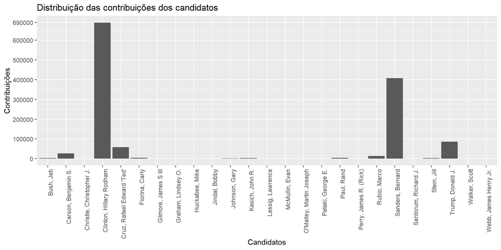

Para melhor compreender a distribuição das contribuições dos candidatos, o gráfico anterior mas usando escala de log.

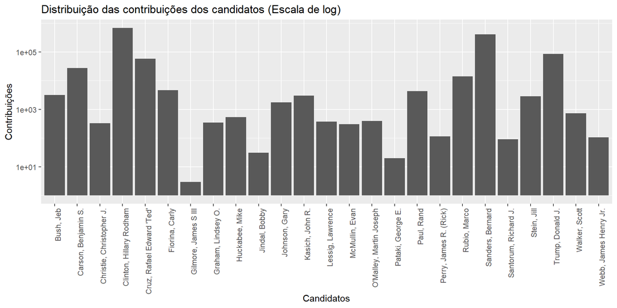

Uma análise dos 5 candidatos com mais contribuições.

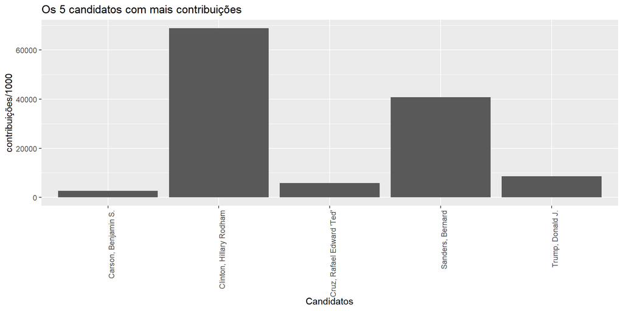

Continuando a exploração, o dataset permite a distribuições das contribuições por cidades, a registro de 2534 cidades, as 20 com maior número de contribuição.

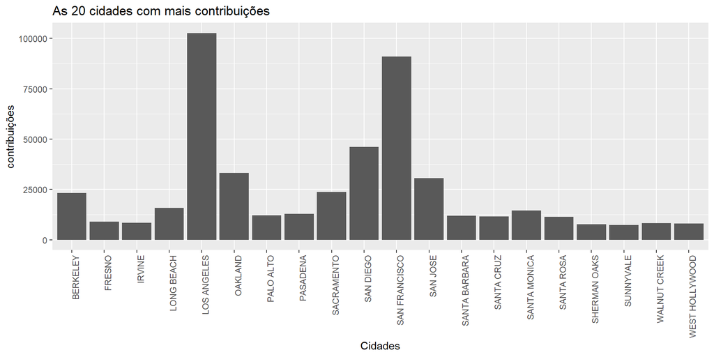

Há registro de 231294 pessoas que realizaram contribuições, As 5 pessoas com maior número de contribuições

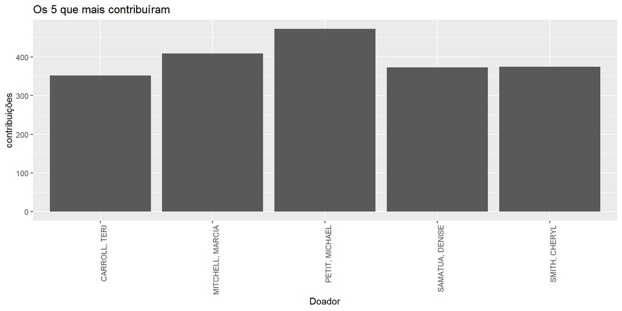

Continuando a exploração, vamos para a tabela de profissão, ela possui o registro de 28622 profissões, no gráfico abaixo a distribuição das 20 profissões que mais contribuíram. Os RETIRED (APOSENTADOS) realizaram 260546 contribuições, aproximadamente 20% das contribuições do dataset. Logo em seguida vem NOT EMPLOYED (DESEMPREGADOS) com 115598 contribuições, aproximadamente 9% do dataset.

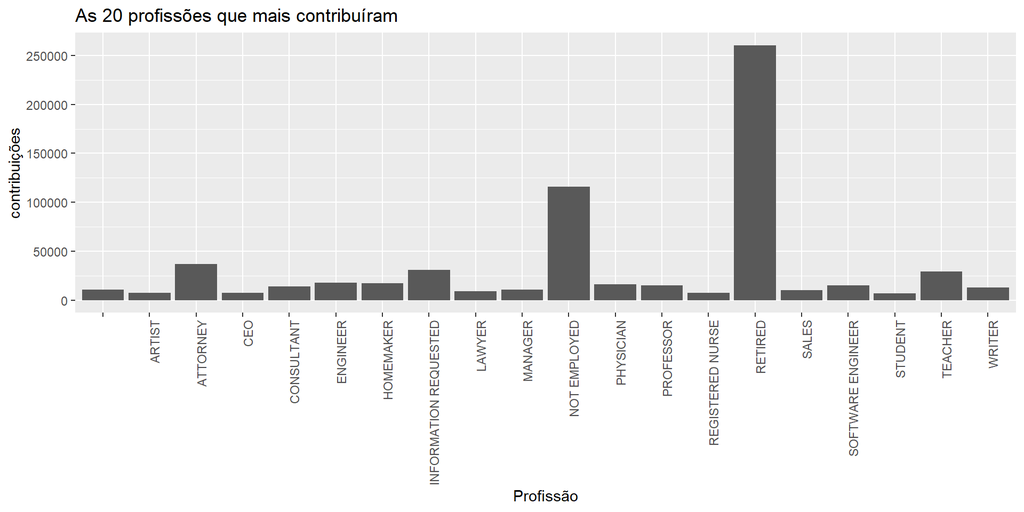

Analisando o valor das contribuições, o valor médio foi 116.2, 16313 está com um valor negativo de contribuição, 53 contribuições tem o valor 0. Para quais candidatos foram direcionadas as contribuições negativas?

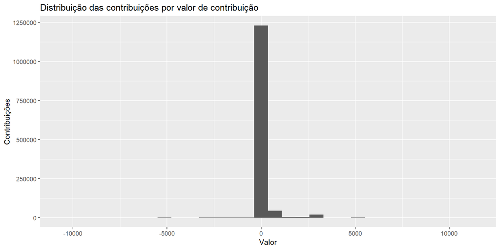

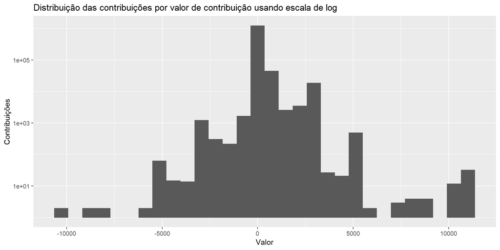

```
##     Min.  1st Qu.   Median     Mean  3rd Qu.     Max.
## -10500.0     15.0     27.0    116.2     88.0  10800.0
```

Contribuições negativas:

```
## [1] 16313    18
```

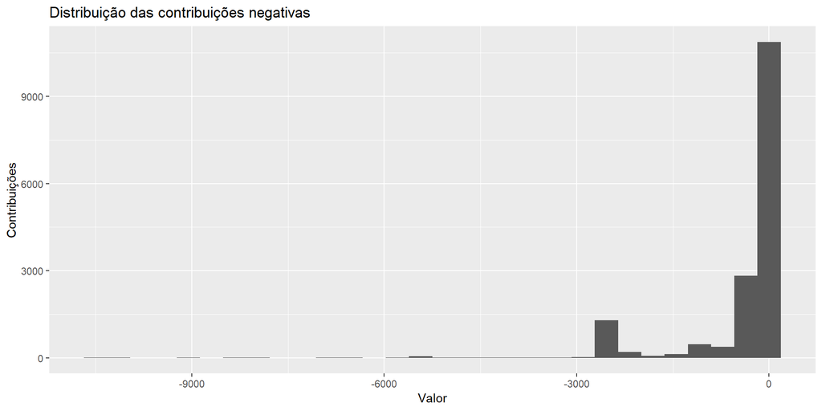

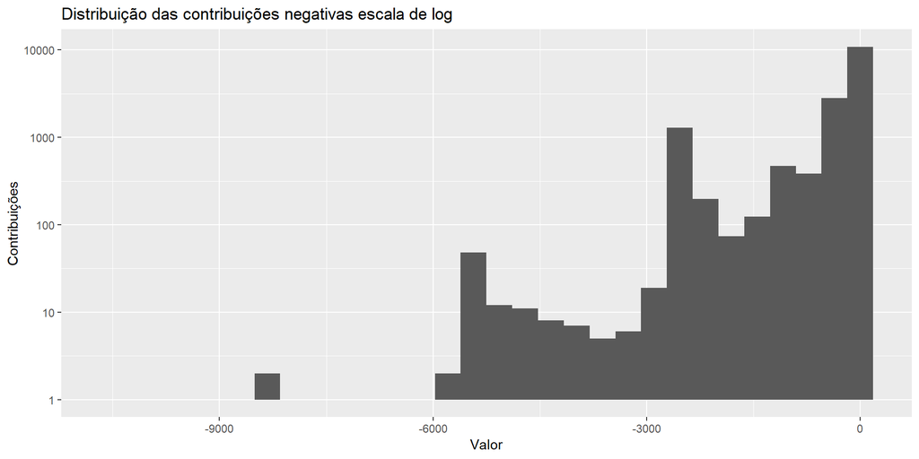

Na distribuição por período, as contribuições se intensificaram no período de FEV/15 à DEZ/16, atingindo a maior quantidade de contribuições em OUT/16

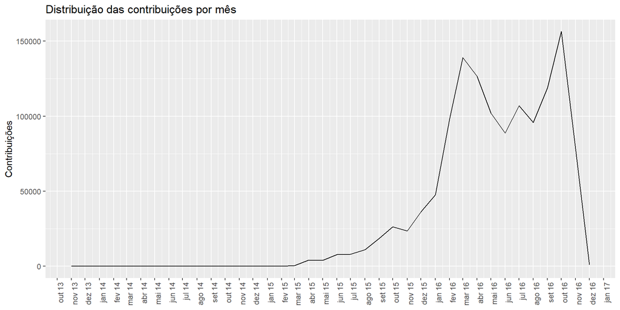

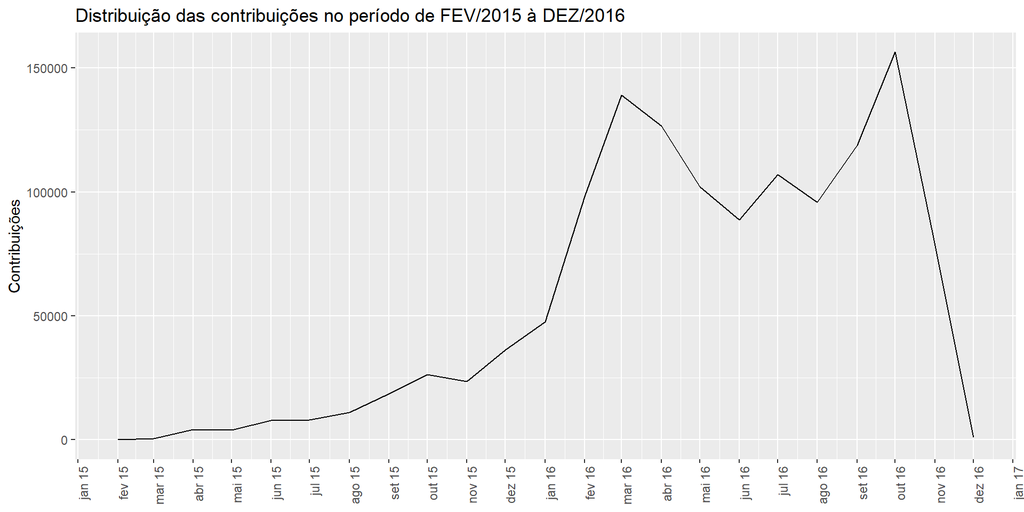

## Analise da variavel

### Qual a estrutura do dataset?

Algumas observações: A candidata Clinton, Hillary Rodham recebeu aproximadamente 53% das contribuições. LOS ANGELES foi a cidade com maior número de contribuições. PETIT, MICHAEL é a pessoa que realizou o maior número de contribuições. Aproximadamente 20% das contribuições foram realizadas por RETIRED (APOSENTADOS). A ocorrência de valores negativos nas contribuições. O ápice de contribuições ocorreu no mês de OUT-16.

### Qual é/são as principais informações do dataset?

As principais informações são nome do candidato(cand_nm) e valor da contribuição(contb_receipt_amt). É possível verificar se a quantidade de contribuições está relacionando com o valor de contribuição recebido.

### Quais outras informações você acha que irão te ajudar na sua investigação?

Nome da cidade(contbr_city), nome do doador(contbr_nm), profissão do doador(contbr_occupation), para verificar a distribuição das contribuições nesses grupos específicos.

### Você criou alguma nova variável a partir das variáveis existentes no seu dataset?

Não.

### Outras informações da sua investigações, existe alguma distribuição incomum? Você realizou alguma operação de ajuste ou mudou a forma das informações? Se sim, por que você fez isso?

Utilizei a escala de log nas contribuições do candidatos, pra visualizar melhor a distribuição das contribuições dos candidatos. Nas contribuições por candidatos também foram selecionados apenas os 5 com maior número de contribuições.  
Também foram selecionadas as 20 cidades com maior número de doações, pois existem o registro de 2534 cidades, o que torna inviável a visualização. O mesmo ocorreu para visualizar as 5 pessoas que mais realizaram contribuições e as 20 profissões que mais contribuíram. Já no valor da contribuição além da escala de log, também foi utilizado um ajuste no eixo x para visualizar uma intervalo especifico, e a seleção no dataset para trazer apenas os valores com contribuições negativas. Na data de contribuição foi realizado uma ajuste para agrupar as datas por mês e um ajuste para visualizar um período especifico.

## Analisando duas variáveis

Agora que descobrimos a distribuição das contribuições no dataset, podemos cruzar as informações, e verificar se existe correlações entre as tabelas.

```
##                         cand_nm    contbr_nm  contbr_city contbr_employer
## cand_nm            1.0000000000 -0.011260328 -0.014973783     0.009349446
## contbr_nm         -0.0112603276  1.000000000 -0.004066966     0.016432681
## contbr_city       -0.0149737834 -0.004066966  1.000000000     0.007510802
## contbr_employer    0.0093494462  0.016432681  0.007510802     1.000000000
## contbr_occupation  0.0003116902 -0.006072176 -0.012023238     0.089475035
## contb_receipt_amt -0.0679612794  0.005109050 -0.004677673     0.009232615
##                   contbr_occupation contb_receipt_amt
## cand_nm                0.0003116902      -0.067961279
## contbr_nm             -0.0060721762       0.005109050
## contbr_city           -0.0120232382      -0.004677673
## contbr_employer        0.0894750347       0.009232615
## contbr_occupation      1.0000000000      -0.026080241
## contb_receipt_amt     -0.0260802407       1.000000000
```

Como mostra os resultados, não existe nenhuma correlação forte, mas isso não impede de continuar a explorar o dataset e buscar algo interessante, por exemplo como no gráfico abaixo, podemos cruzar as informações de candidatos com informações sobre o valor da contribuição. Será que a quantidade de contribuições está diretamente ligada com o valor recebido pelo candidato?

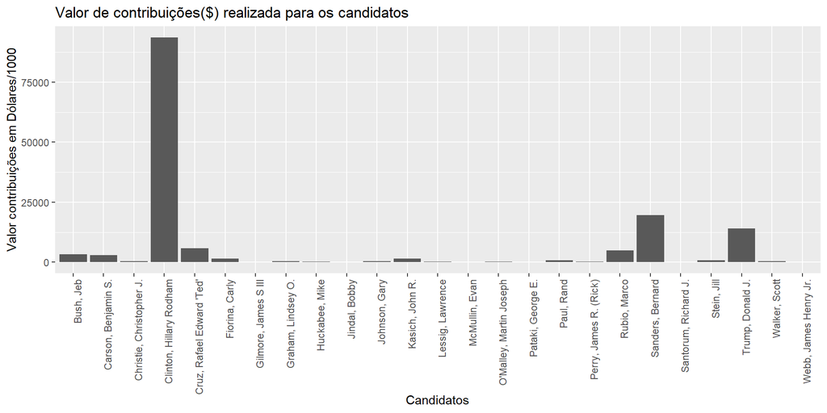

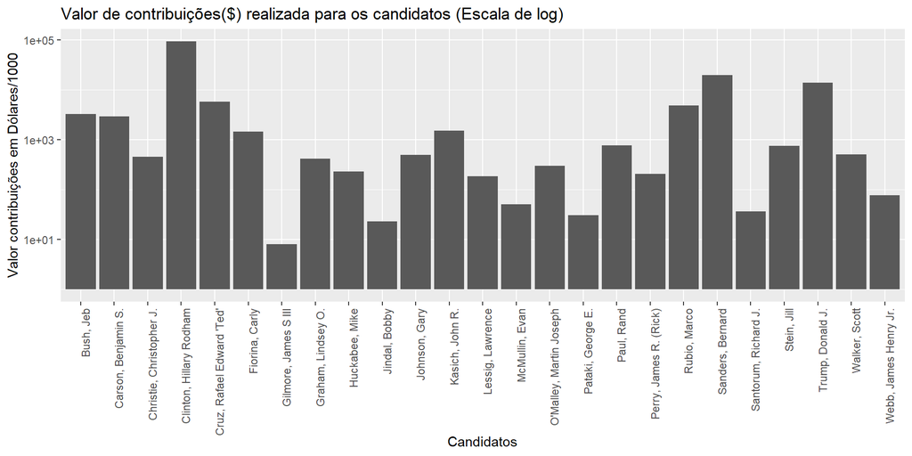

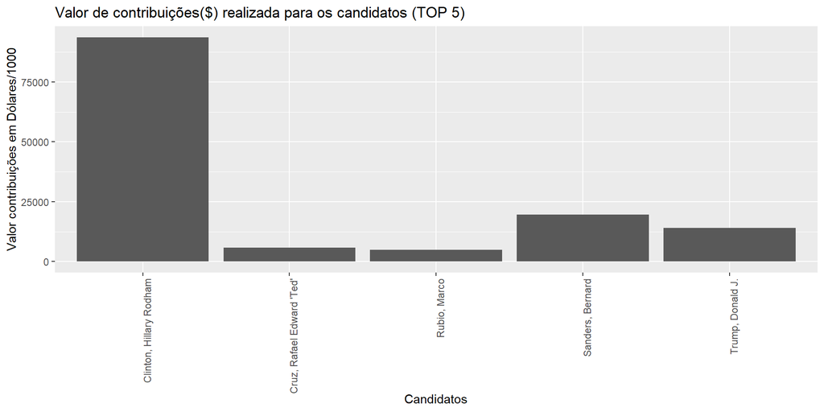

Para melhor visualizar a diferença entre a quantidade de contribuição e o valor recebido, transformei os valores em porcentagem, assim podemos visualizar a representação de cada um. Em vermelho a porcentagem que o candidato tem em relação aos valores das contribuições e em azul a quantidade.

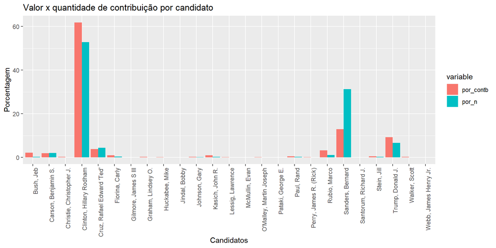

A candidata Clinton, Hillary Rodham possui aproximadamente 53% da quantidade de contribuições e recebeu aproximadamente 62% do valor contribuído. O candidato Sanders, Bernard por sua vez tem 31% da quantidade de contribuições, mas representa apenas 13% do valor contribuído. O candidato Carson, Benjamin S. aparecia entre os 5 com maiores números de contribuições, porém não aparece no top 5 dos que receberam mais em valor.

Com base nessas informações fica a dúvida sobre a correlação entre o número de contribuições com o valor. Segue abaixo o resultado do teste.

```
## [1] 0.9401935
```

O resultado mostra que existe um alto índice de correlação entre eles. O gráfico abaixo mostra essa correlação, para uma melhor analise, o eixo x e y estão em escala de log.

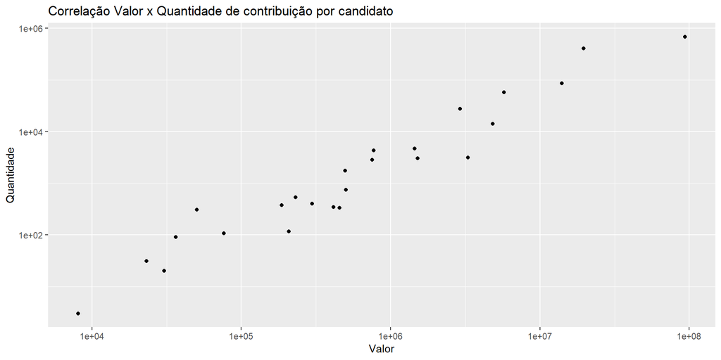

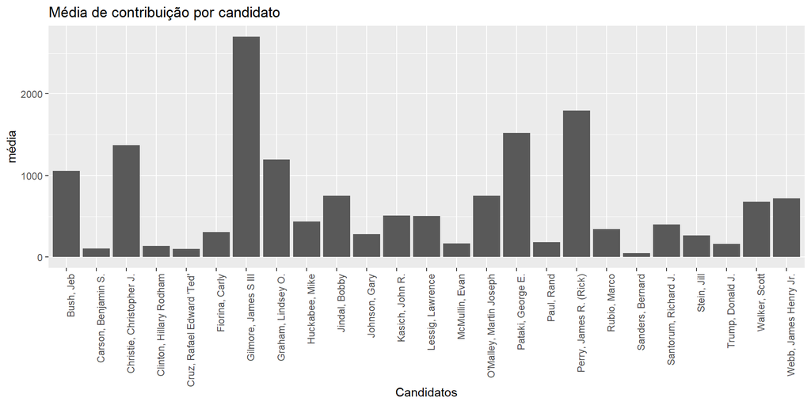

A média mostrou um fato curioso, o candidato Gilmore, James S III, teve a maior média, porém ao analisar especificamente esse candidato, ele obteve apenas 3 contribuições, foi o candidato com menor contribuição, tanto em valores quanto em quantidade.

```
##                     cand_nm             contbr_nm          contbr_city
## 872946 Gilmore, James S III    CREEDON, W. L. MR. LA CANADA FLINTRIDGE
## 873585 Gilmore, James S III JOHANSON, N. ERIC MR.               SYLMAR
## 873586 Gilmore, James S III   LEVITT, MICHAEL MR.          LOS ANGELES
##                   contbr_employer     contbr_occupation contb_receipt_amt
## 872946  U.B.S. FINANCIAL SERVICES     FINANCIAL ADVISOR              2700
## 873585 JOHANSON DIELECTRICS, INC.                   COB              2700
## 873586   APOLLO GLOBAL MANAGEMENT INVESTMENT MANAGEMENT              2700
##        contb_receipt_dt
## 872946       2015-08-12
## 873585       2015-08-03
## 873586       2015-09-22
```

A distribuição das contribuições negativas entre os candidatos também é algo interessante de ser visualizado:

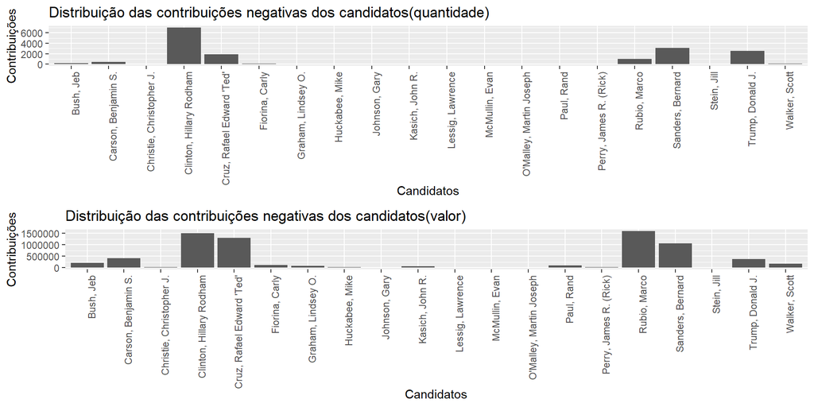

Podemos também realizar as analisar a tabela de valor com as outras tabelas.

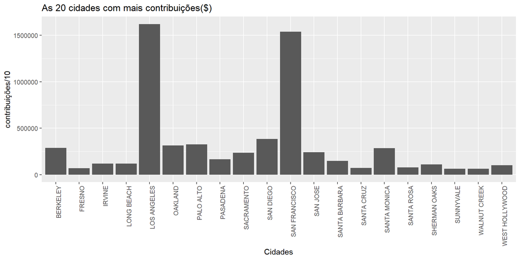

Podemos verificar a correlação de valor e quantidade, mas agora com o foco na contribuição por cidade.

```
## [1] 0.9609861
```

Existe um alto índice de correlação, um pouco melhor comparado a correlação do grupo de candidatos.

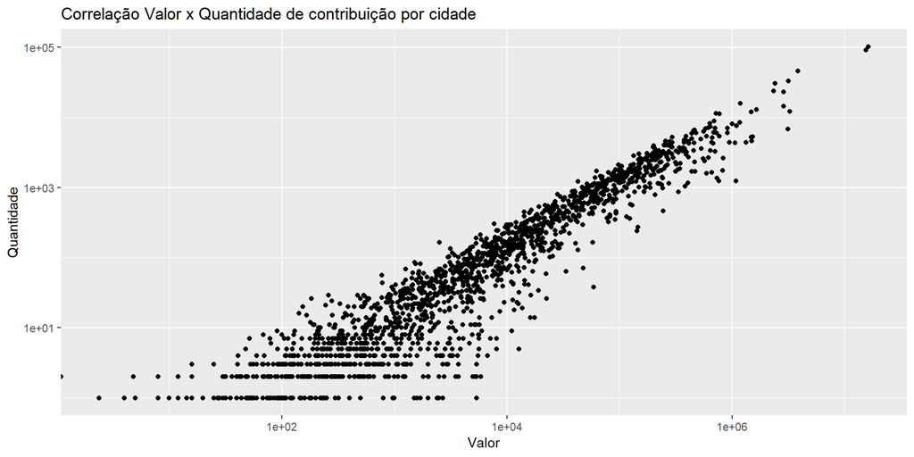

A seguir os doadores que mais doaram($), e também correlação entre quantidade de contribuições e valor.

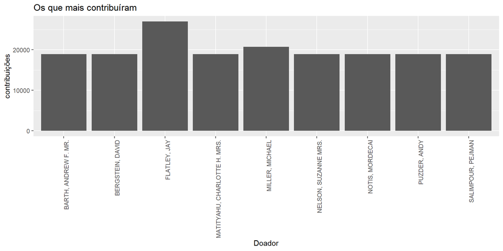

```
## [1] 0.2006902
```

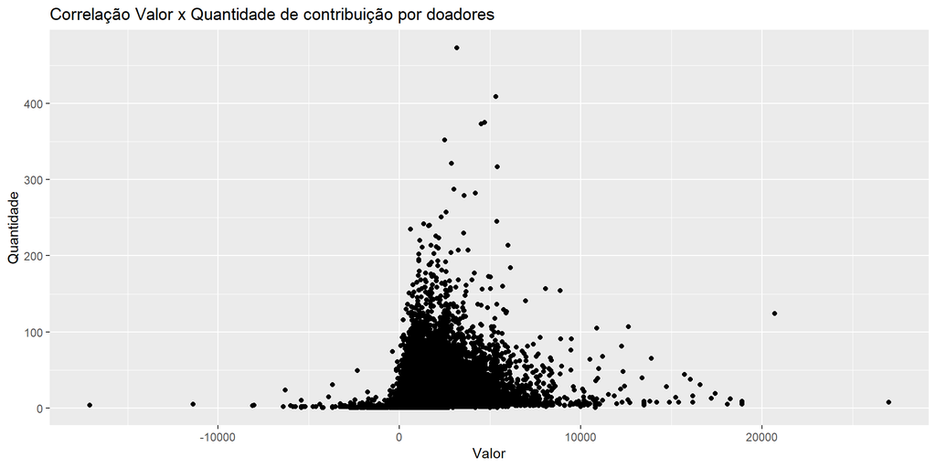

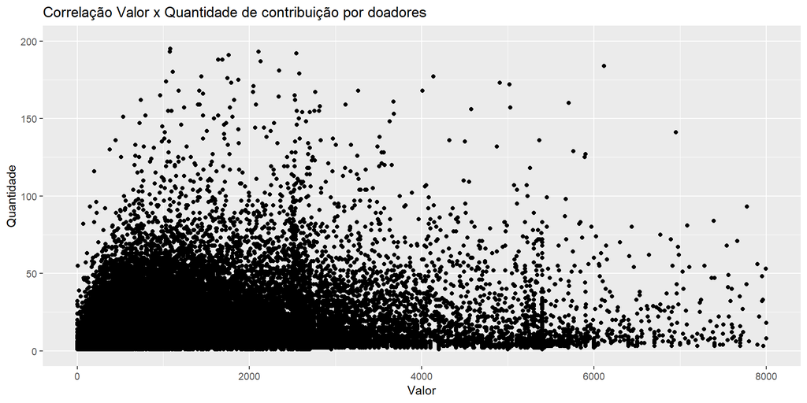

Baixo índice de correlação entre quantidade de contribuições e valor. Vamos verificar o que ocorre com as profissões.

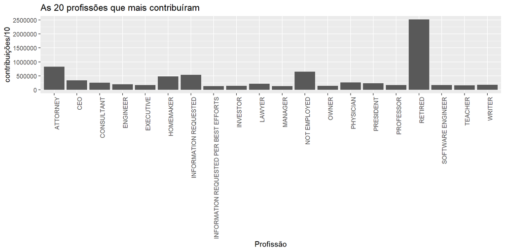

```
## [1] 0.9353817
```

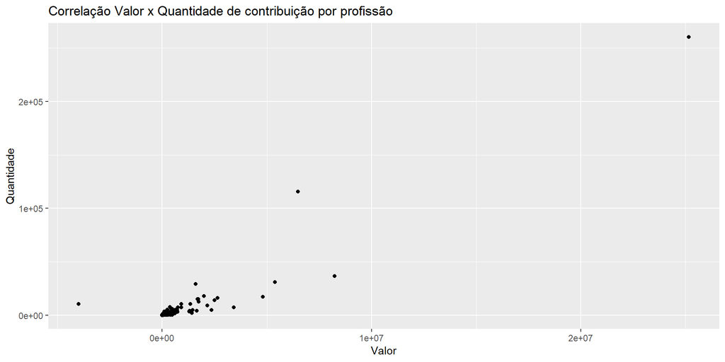

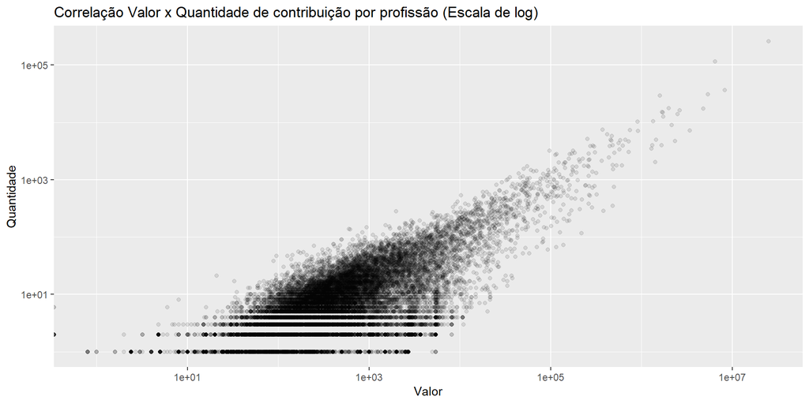

Apresenta um alto indicie de correlação, no gráfico acima o eixo x e y estão em escala de log, e usado alpha = 1/10.

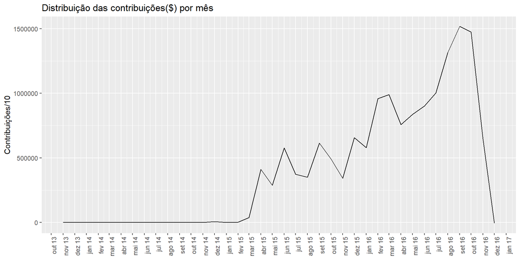

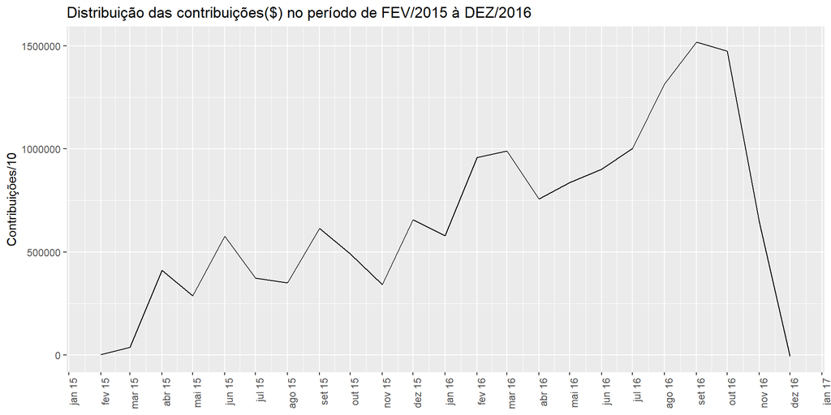

Ao contrário do gráfico por quantidade que mostrava o pico de contribuição no mês de out/10, esse gráfico nos mostra que o pico de contribuição em valor, ocorre no set/16.